# lab2_Whitney_Willoz

Answer:The number of ratings is higher in Peru and Venezuela so higher producing companies probably have more ratings.

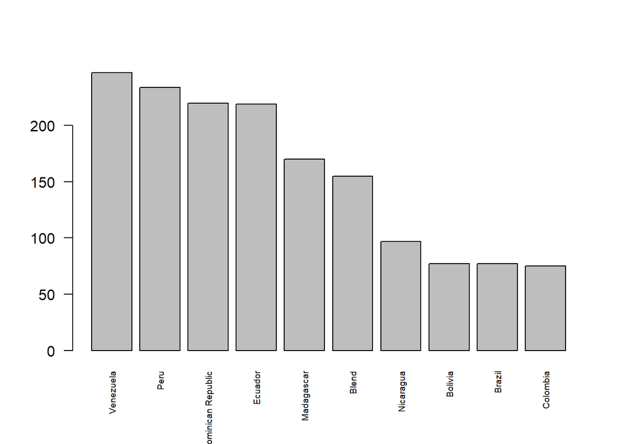

```r
beanOrigins <- table(choco$CountryBeanOrigin)
beanOrigins1<- sort(beanOrigins, decreasing = TRUE)
beanOrigins2 <- head(beanOrigins1, 10)
barplot(beanOrigins2, las = 2, cex.names = 0.6)
```

3.Do ratings depend on the cacao percentage of a chocolate bar? Create both numerical and graphical summaries, and explain. [Hint: Think about why the scatterplot is not a very good choice for visualization here.]

```r
summary(choco$CocoaPercent)
```

```
##    Min. 1st Qu.  Median    Mean 3rd Qu.    Max.
##   42.00   70.00   70.00   71.65   74.00  100.00
```

```r
summary(factor(choco$CocoaPercent))
```

```
##   42   46   50   53   55   56   57   58   60 60.5   61   62   63   64   65   66
##    1    1    1    1   16    2    1    8   46    1    7   15   14   34   90   28
##   67   68   69   70   71 71.5   72 72.5   73 73.5   74   75   76   77   78   79
##   34   68   12 1003   43    2  284    4   63    2   65  302   34   41   20    2
##   80   81   82   83   84   85   86   87   88   89   90   91   99  100
##   88    6   18    4    4   40    1    1    8    2    9    3    2   21
```

```r
summary(factor(choco$Rating))
```

```
##    1  1.5 1.75    2 2.25  2.5  2.6 2.75    3 3.25  3.5 3.75    4
##    4   10    3   33   17  161    1  329  512  443  538  293  108
```

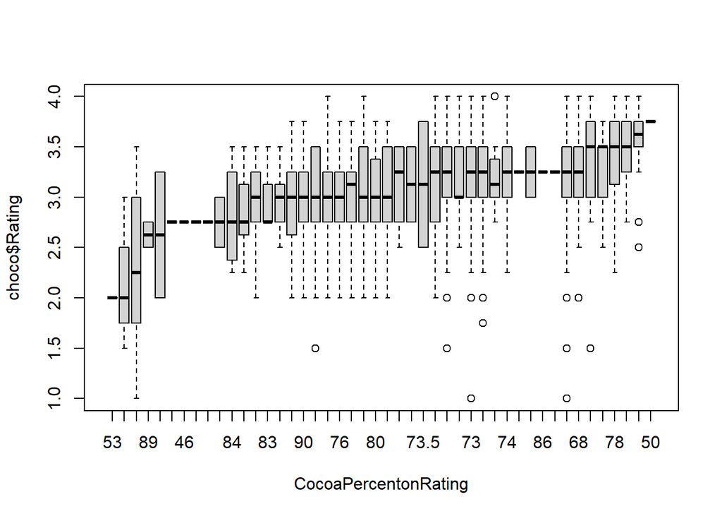

```r
CocoaPercentonRating <- reorder(factor(choco$CocoaPercent), choco$Rating, FUN=mean)
boxplot(choco$Rating ~ CocoaPercentonRating)
```

## Exploration

4.How do different bean origins compare in terms of the flavor of chocolates? Are beans from some places better than the other? Create both numerical and graphical summaries, and explain.

```r
library(tidyverse)
```

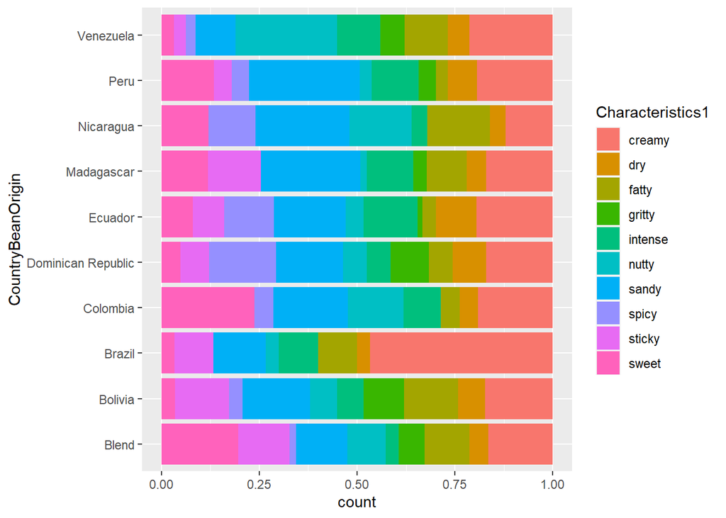

```r
flavor <- table(choco$Characteristics1)
flavor_filtered <- flavor[flavor > 50]
choco_filtered <- filter(choco, Characteristics1 %in% names(flavor_filtered))

country_filtered <- table(choco$CountryBeanOrigin) %>%
  sort(decreasing = TRUE) %>%
  head(10) # select the top 10 countries

choco %>%
  filter(Characteristics1 %in% names(flavor_filtered)) %>% # filter flavor
  filter(CountryBeanOrigin %in% names(country_filtered)) %>% # filter country
  ggplot() +
  geom_bar(aes(x = CountryBeanOrigin, fill = Characteristics1), position = 'fill') +
  coord_flip()
```

```r
tapply(choco$Rating, choco$CountryBeanOrigin, summary) %>%
  head(5)
```

```
## $Australia
##    Min. 1st Qu.  Median    Mean 3rd Qu.    Max.
##    2.75    3.00    3.25    3.25    3.50    3.75
##
## $Belize
##    Min. 1st Qu.  Median    Mean 3rd Qu.    Max.
##   2.500   3.000   3.250   3.236   3.500   4.000
##
## $Blend
##    Min. 1st Qu.  Median    Mean 3rd Qu.    Max.
##   1.000   2.750   3.000   3.037   3.500   4.000
##
## $Bolivia
##    Min. 1st Qu.  Median    Mean 3rd Qu.    Max.
##   2.000   3.000   3.250   3.175   3.500   4.000
##
## $Brazil
##    Min. 1st Qu.  Median    Mean 3rd Qu.    Max.
##   1.750   3.000   3.250   3.263   3.500   4.000
```

5.brainstorm two analyses you would like to perform. Describe in plain language what comparisons are you making. Create suitable numerical and graphical summaries for your analyses. Describe the results.

Analysis 1:Do chocolates from the US location have a typical lower rating than that of the French?

Answer: On average the French have a higher rating of their chocolate than the US. But only by A very slim bit because there are just more observations of the US that vary.

```r
franceL <- choco[choco$Location == "France",]
franceM <- mean(franceL$Rating)
franceM
```

```
## [1] 3.254286
```

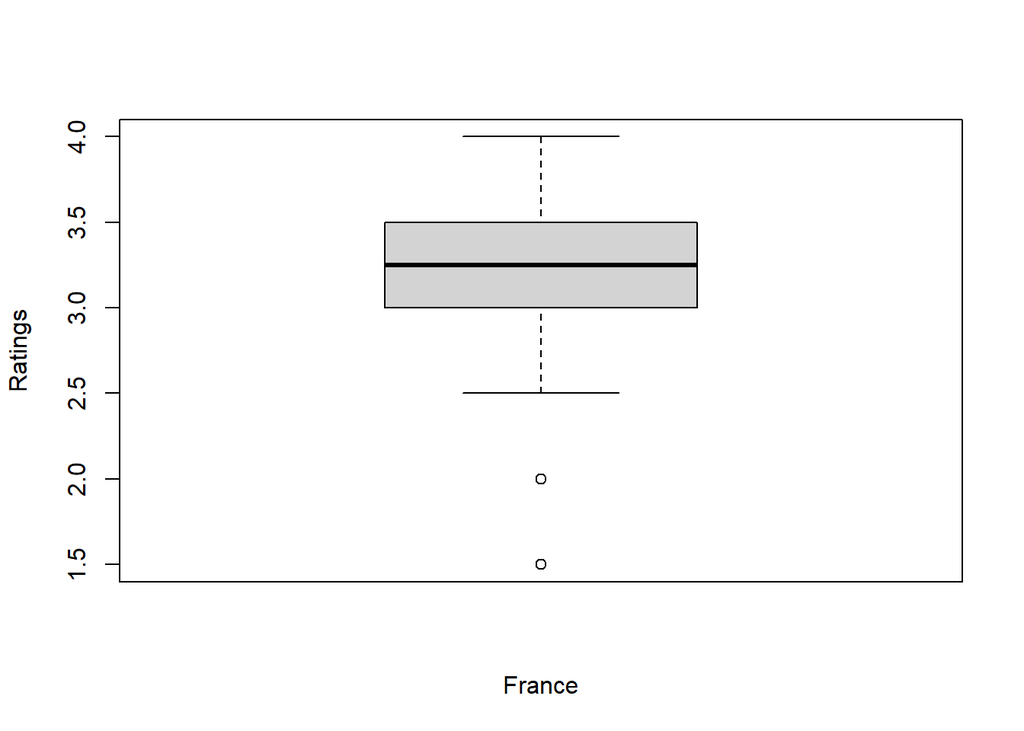

```r
boxplot(franceL$Rating, xlab = "France", ylab = "Ratings")
```

```r
USL <- choco[choco$Location == "U.S.A.",]
USM <- mean(USL$Rating)
USM
```

```
## [1] 3.184972
```

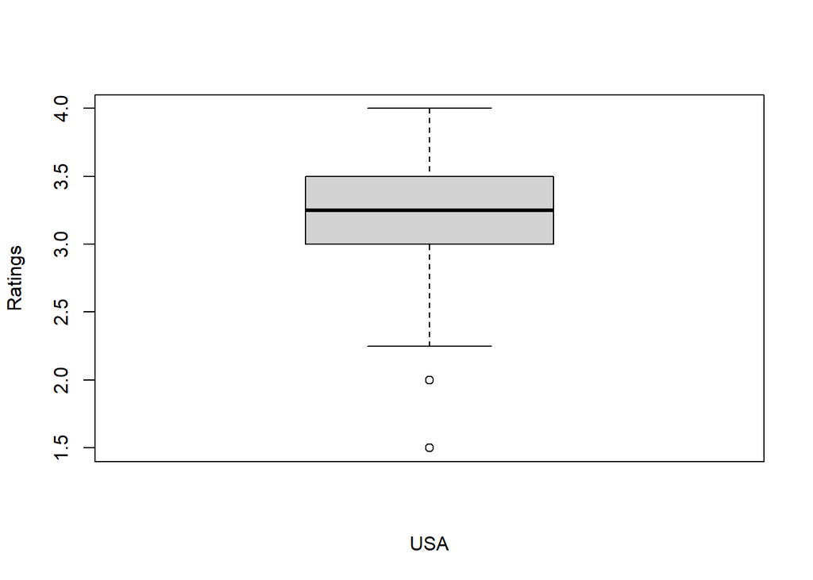

```r
boxplot(USL$Rating, xlab = "USA", ylab = "Ratings")
```

Analysis 2:Does Amatller (Simon Coll) have a higher rating than Artisan du Chocolat company?

Answer:Amatller (Simon Coll) has a lower average rating and a smaller spread of ratings meaning they must produce lower quality chocolate than Artisan du Chocolat.

```r
AmaC <- choco[choco$Company == "Amatller (Simon Coll)", ]
AmaM <- mean(AmaC$Rating)
AmaM
```

```
## [1] 2.875
```

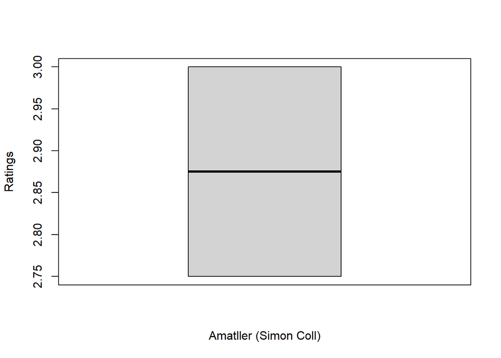

```r
boxplot(AmaC$Rating, xlab = "Amatller (Simon Coll)", ylab = "Ratings")
```

```r
ArtC <- choco[choco$Company == "Artisan du Chocolat", ]
ArtM <- mean(ArtC$Rating)
ArtM
```

```
## [1] 3.078125
```

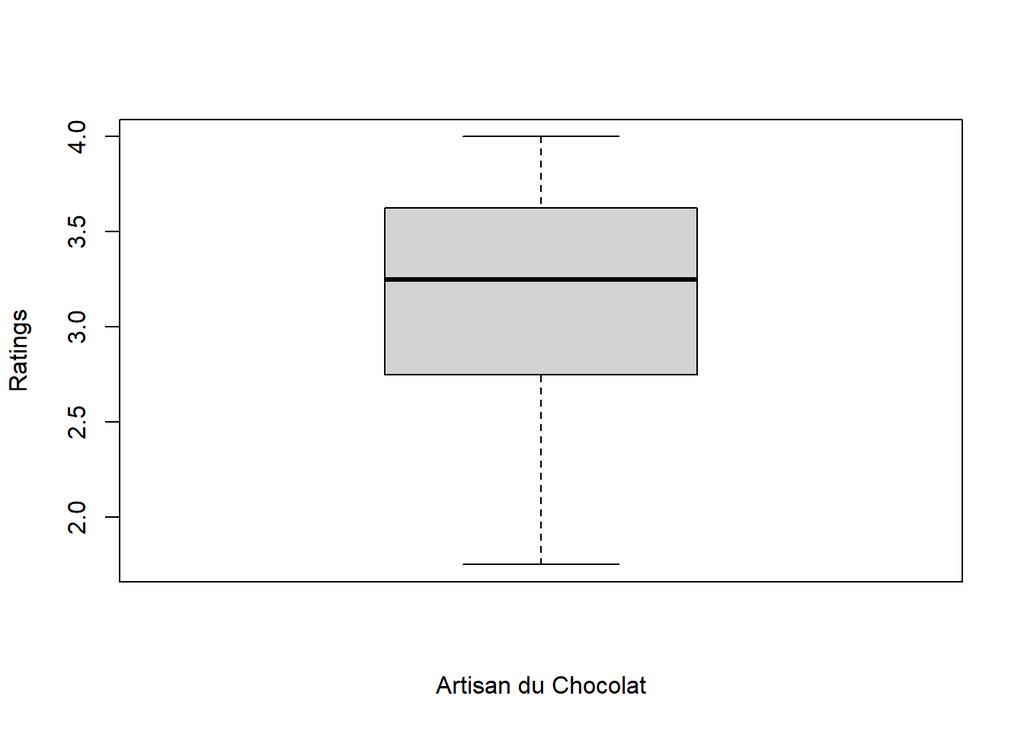

```r
boxplot(ArtC$Rating, xlab = "Artisan du Chocolat", ylab = "Ratings")
```